# FIA Data Review

Jennifer Truong

6/29/2020

## Observing Unique Species

Conifer species we are focusing on for our GP:

| Scientific Name | Common Name | Code |
| --- | --- | --- |
| Pinus ponderosa | Ponderosa pine | PIPO |
| Pinus jeffreyi | Jeffery pine | PIJE |
| Pinus coulteri | Coulter pine | PICO3 |
| Pinus lambertiana | Sugar pine | PILA |
| Pseudotsuga macrocarpa | Big cone douglas fir | PSMA |
| Abies concolor | White fir | ABCO |
| Calocedrus decurrens | Incense cedar | CADE |
| Pinus contorta ssp. murrayana | Lodgepole pine | PICO/PICOM |

## ANF Data Analysis

### ANF Data Collection Dates

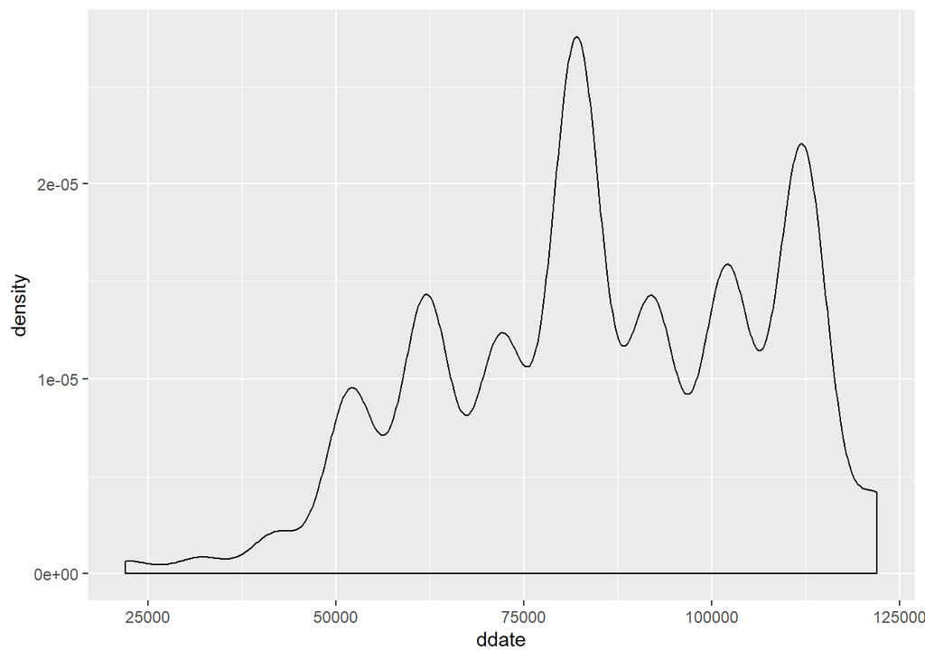

### ANF Conifer Count

| species | n |
| --- | --- |
| ABCO | 66 |
| CADE27 | 10 |
| PICO | 9 |
| PICO3 | 5 |
| PIJE | 89 |
| PILA | 29 |
| PIPO | 1 |
| PSMA | 48 |

### ANF Trees per Plot

| plot | n |
| --- | --- |
| 1 | 18 |
| 13 | 3 |
| 14 | 1 |
| 17 | 6 |
| 18 | 9 |
| 20 | 1 |
| 30 | 6 |
| 33 | 3 |
| 34 | 11 |
| 41 | 1 |
| 62 | 1 |
| 105 | 9 |
| 106 | 16 |
| 114 | 2 |
| 116 | 1 |
| 118 | 3 |
| 119 | 8 |
| 121 | 7 |
| 124 | 12 |
| 125 | 11 |
| 126 | 5 |
| 128 | 6 |
| 129 | 1 |
| 131 | 7 |
| 142 | 1 |
| 152 | 14 |
| 153 | 15 |
| 154 | 3 |
| 158 | 5 |
| 173 | 7 |
| 183 | 15 |
| 192 | 18 |
| 195 | 4 |
| 196 | 10 |
| 197 | 17 |

### ANF Missing Data

| variable | n_miss | pct_miss |
| --- | --- | --- |
| dist | 6878 | 100.00 |
| comp | 6878 | 100.00 |
| stan | 6878 | 100.00 |
| strc | 6878 | 100.00 |
| hist | 6878 | 100.00 |
| hsdt | 6878 | 100.00 |
| dacc | 6878 | 100.00 |
| spfe | 6878 | 100.00 |
| optc | 6878 | 100.00 |
| gfrm | 6163 | 89.60 |
| srfc | 4425 | 64.34 |
| ecot | 2863 | 41.63 |
| lfrm | 2453 | 35.66 |
| species | 2453 | 35.66 |
| forest | 0 | 0.00 |
| plan | 0 | 0.00 |
| stra | 0 | 0.00 |
| splt | 0 | 0.00 |
| plot | 0 | 0.00 |
| ddate | 0 | 0.00 |
| invt | 0 | 0.00 |
| site | 0 | 0.00 |
| aspc | 0 | 0.00 |
| slop | 0 | 0.00 |
| elev | 0 | 0.00 |
| trid | 0 | 0.00 |
| poin | 0 | 0.00 |
| ncnt | 0 | 0.00 |
| fact | 0 | 0.00 |
| r5tc | 0 | 0.00 |
| covr | 0 | 0.00 |
| heig | 0 | 0.00 |
| ntpa | 0 | 0.00 |
| pclu | 0 | 0.00 |
| psta | 0 | 0.00 |
| pstr | 0 | 0.00 |
| cstr | 0 | 0.00 |
| gis_link | 0 | 0.00 |
| project_name | 0 | 0.00 |
| fld_id | 0 | 0.00 |

### ANF FIA Data Summary

- The total number of data points recorded in the FIA data for ANF is 6878. There are 4425 data points recorded as actual plant trees.
- There are 139 plots in ANF.
- A total of 271 unique plant species are recorded in this FIA dataset. Only 8 of these are our conifer species of interest.
- 257 trees are recorded as conifer trees.
- 4168 are recorded as other plant species.
- There are 2453 missing values in the species column.